# Stat 331 Final Project

# Introduction

**Data and Variable Descriptions**:

We chose to explore the relationship between child mortality rates and average daily income by country from the years 1800 to 2023. In order to find data for this, we selected two datasets from Gapminder, one for each of our quantitative variables. For our first variable, we are measuring child mortality by country as the number of 0-5 year olds dying per 1000 babies born, and for income we are measuring average daily household per capita income adjusted for inflation and price. Without controlling for inflation, we would see a near constant increase in income by year, but by controlling for income by expressing every income in 2017 US dollars we can better compare different countries since we are standardizing the value of the dollar across all data points.

It is also important to consider the origins and logic behind the procurement of these datasets as Gapminder has extrapolated and made rough estimates of changes in both of these datasets that are not necessarily accurate. Within the child mortality rates dataset, Gapminder combined data from multiple sources ranging in methodology as some of the mortality rates are calculated based on regression analysis while others are simply projected estimates. This, coupled with the varying yearly ranges leads to a patchwork of datasets to create the dataset we are analyzing which could eliminate the relevancy of our analysis. The mean income per capita dataset faces a similar problem as the various countrys’ income distributions are calculated via different methods based on the prevalency of data. If countries do not have a mean income indicator from the World Bank with data from household surveys, daily incomes per household are instead estimated based on the country’s GDP per capita. These factors should be considered in assessing the relevancy, accuracy, and value of our analysis between the two variables in question.

**Hypothesis:**

Our hypothesis is that we will see an inverse relationship between each countries child mortality rate and average daily income, or that as income increases, child mortality decreases by country. We would expect childcare and medical care to be better and more readily available in countries as income increases, decreasing the child mortality rate. A greater daily household income also indicates a larger economy with better technology to treat emergencies leading to improved citizen welfare. While there are numerous other confounding variables that also effect child mortality rate, we will only focus on the relationship between average daily income and child mortality rate, and it is important to acknowledge that our analysis may prove association but not necessarily causation between the two varaibles.

# Section 1.1: Data Cleaning and Pivoting

Our goal in data cleaning is looking to create clean and tidy data that we can easily analyze. First, we checked for any missing values in the data:

```
[1] 0
```

```
[1] 1800
```

We found that our daily income data set (income) has zero missing values, but our child mortality data set is missing 1800 entries.

We investigated the nature of our missing values, learning that they are not random, but rather some countries do not have any values for any years. These countries cannot be included because we need at least some entries to perform analysis on, so we will ommit them from our analysis.

# Section 1.3: Joining Datasets

# Section 2.1: Data Visualization

Our first data visualization is a scatterplot that explores the relationship of child mortality and daily income over time. Each point on the plot represents a country’s child mortality rate and daily income for an individual year. We do not see an exactly linear relationship, rather a slightly parabolic curve as child mortality rate decreases as daily income increases. There are few real outliers in this data, as most points are packed very tightly together.

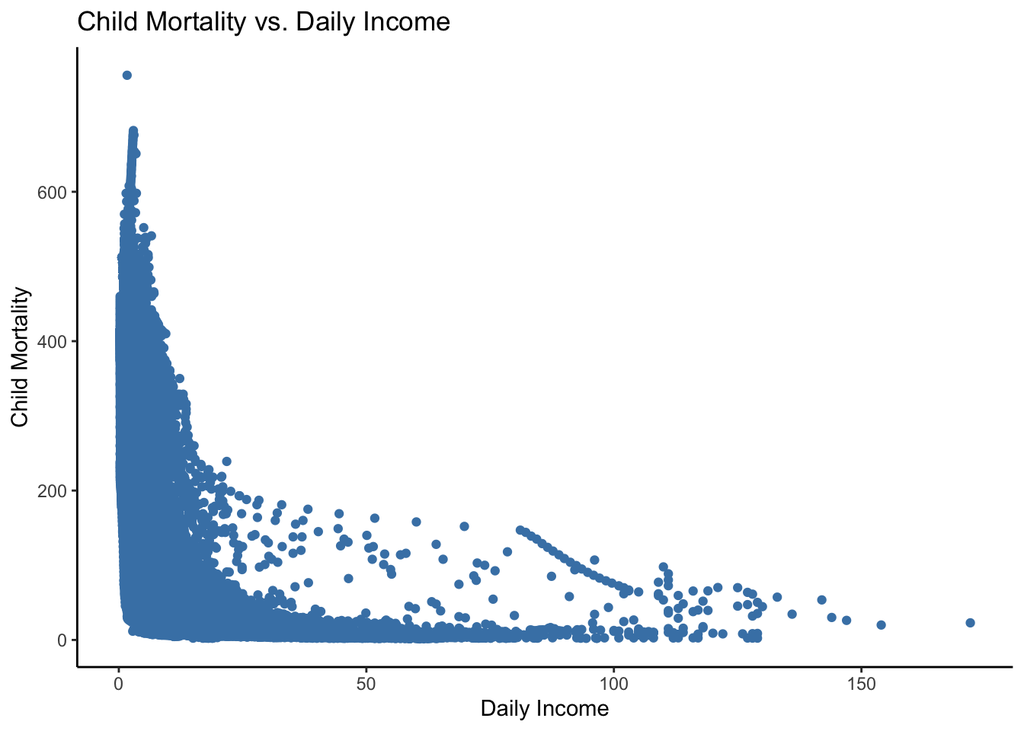

While the above graph shows us the relationship of daily income and child mortality over all years for all countries, we are curious to see how the relationship between daily income and child mortality has changed over time. Below, is an animated scatterplot that displays the relationship between child mortality and daily income by year. We see that as more time passes, child mortality rate drops, and daily income starts to move higher up. We see that daily income increases the most after 1960, while child mortality continues to get closer to 0.

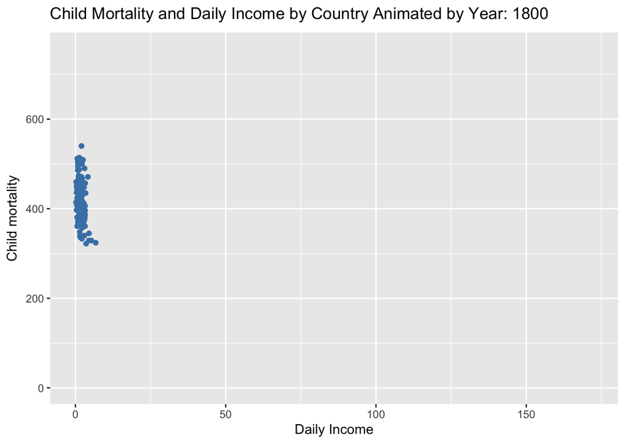

# Section 2.2: Linear Regression:

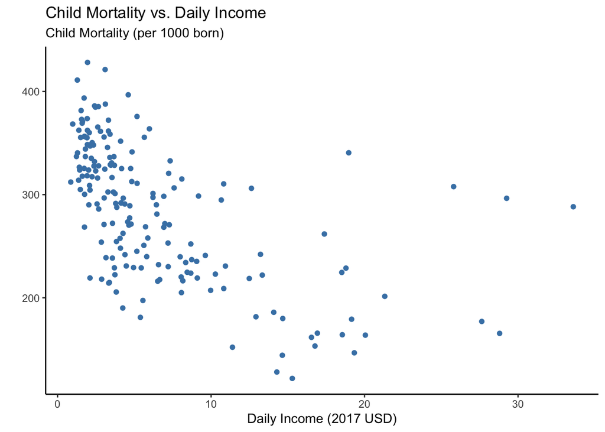

# Section 2.3: Model Fit

| Measure | Variance |
| --- | --- |
| Response Variance | 4333.415 |
| Fitted Variance | 1960.840 |
| Residual Variance | 2372.574 |

# Section 3.1:

Using our linear regression model, we generated predictions for child mortality and added random error to them. below is the side by side plots of our simulated response on the left and our acutal data on the right.

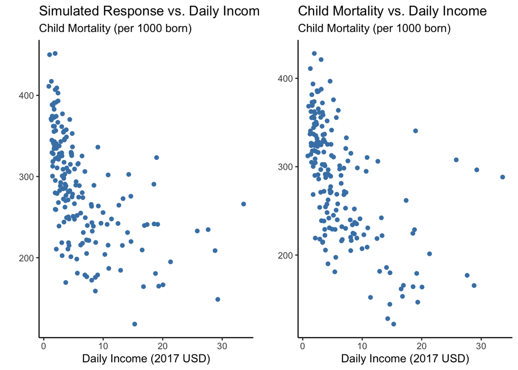

Our Simulated data and our actual observations follow a similar downward slopping pattern, with our observations being more concentrated around low daily income and high child mortality. One of the main differences between our simulated and observed is that our actual observations have some outliers with both a very high average daily income and high child mortality rate. Overall, our simulated data ligns up very well with our observed data. But, to see if our model holds up, we will generate one thousand simulated datasets to perform predictive checks.

# Section 3.2: Generating Multiple Predictive Checks

We generated 1000 simulated data sets in order to see if they could have been observed based on our regression model. We then regressed our observed dataset against each simulated response, then took the $R^2$ value from each regression and plotted them below:

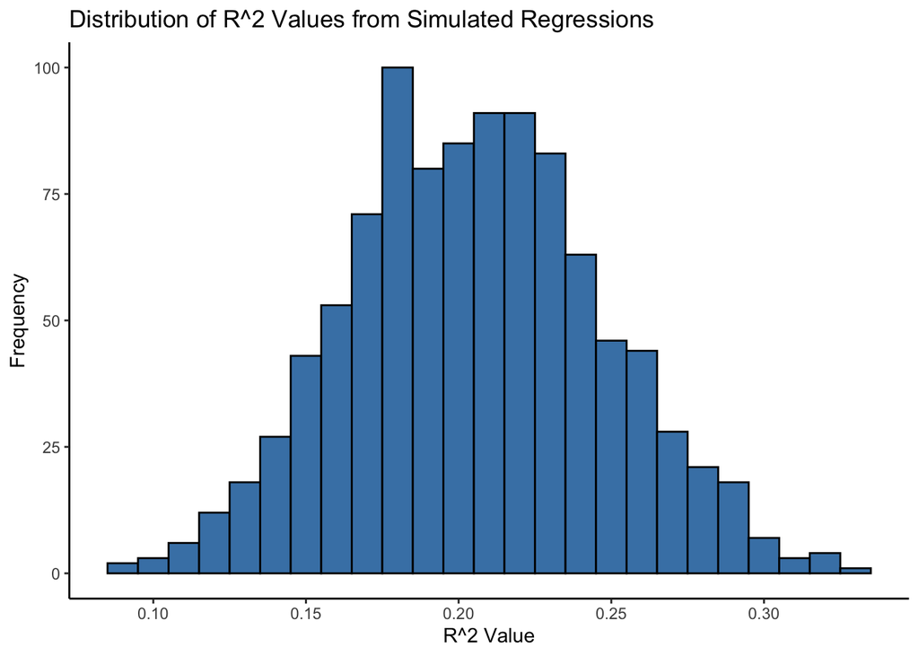

Our simulated $R^2$ values follow a normal distribution, which should be expected given that we added normally distributed random error. It is centered around a $R^2$ of .2, meaning that on average our simulated data sets derived from our regression explains 20% of the variability in our observed data. when creating simulated data sets, our regression leaves 80% of the variability in our original data unexplained.

# Conlusion

The hypothetized relationship explored in this report was the relationship between average daily income and child mortality across 185 countries. We suspected that as average daily income increased, child mortality would decrease. In order to test this relationship, we created a linear regression model, and found a negative relationship between the two variables.